# Lecture 11 - R Code

Creating Variogram Plots in R

This is essentially a replication of the code used in the lecture notes, The only difference is it is a little less condenced and in HTML.

# Preamble

## Import Library

The following code will automatically install packages that are not already installed and load them into the library:

```r
if(require('pacman')){
  library('pacman')
}else{
  install.packages('pacman')
  library('pacman')
}
pacman::p_load(sp, EnvStats, gstat, ggplot2, rmarkdown)
```

## Create Assignments

```r
#Assignments
benthic <- Benthic.df
lat <- benthic$Latitude
lon <- benthic$Longitude
```

# Create a Variogram

```r
coordinates(benthic) = ~Longitude + Latitude
benthic.vg <- variogram(Index ~ 1, data = benthic)
```

## Create a base plot of that variogram

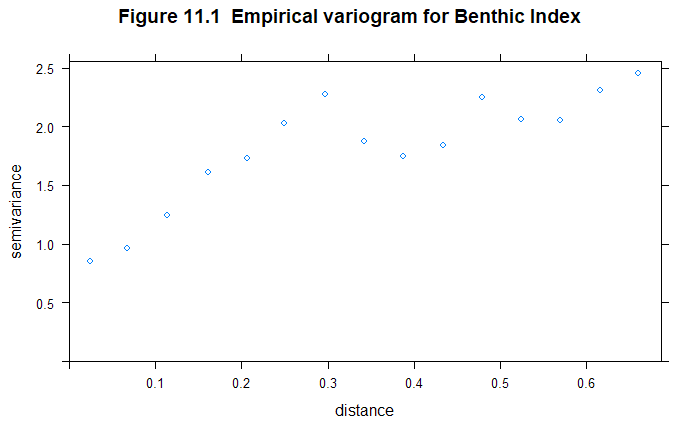

```r
plot(benthic.vg, main="Figure 11.1  Empirical variogram for Benthic Index")
```

## Create an attractive plot in ggplot

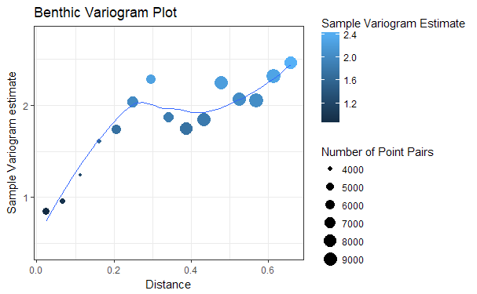

```r
ggplot(data = benthic.vg, aes(x = dist, y = gamma, col = gamma, size = np)) +
  geom_point() +
  labs(size = "Number of Point Pairs", col = "Sample Variogram Estimate",
       y = "Sample Variogram estimate", x = "Distance",
       title = 'Benthic Variogram Plot') +
  theme_bw() +
  geom_smooth(alpha = 0, size = 0.5)
```

# Fit a Variogram Model

There are three common models for variograms:

- Exponential
  - $C(h) = \sigma^2 \times e^{\frac{-h}{r}}$
- Gaussian
  - $C(h) = \sigma^2 \times e^{({\frac{-h}{r}})^2}$
- Spherical
  - $C(h) = \sigma^2 \times (1 - \frac{3h}{2r} + \frac{h^2}{2r^3})$

Unfourtunately `ggplot2` cannot take an object of class `variogramModel` and plot it (atleast I cant figure out how to do it), hence it is necessary to use the base package to plot the model over the points.

It also does not appear possible to comine the plots using `par(mfrow = c(1,3))`.

## Plot the model over the variogram

### Exponential

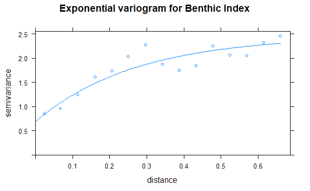

```r
benthic.vg.fit.exp <- fit.variogram(benthic.vg,
                                    model=vgm(1,"Exp", 0.5,1))
plot(benthic.vg, benthic.vg.fit.exp,
     main="Exponential variogram for Benthic Index")
```

### Gaussian

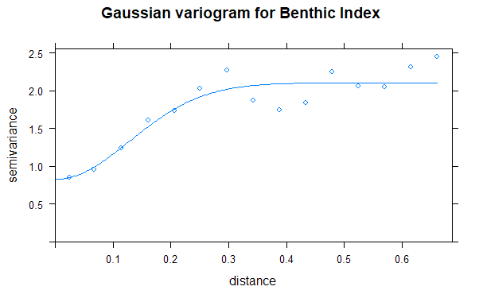

```r
benthic.vg.fit.gau <- fit.variogram(benthic.vg,
                                    model=vgm(1,"Gau", 0.5,1))
plot(benthic.vg, benthic.vg.fit.gau,
     main="Gaussian variogram for Benthic Index")
```

### Spherical

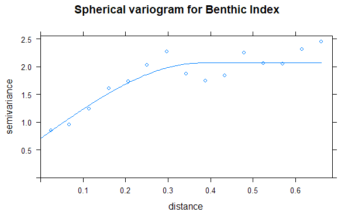

```r
benthic.vg.fit.sph <- fit.variogram(benthic.vg,
                                    model=vgm(1,"Sph", 0.5,1))
plot(benthic.vg, benthic.vg.fit.sph,
     main="Spherical variogram for Benthic Index")
```

# Directional Variograms

Because a directional variogram is still of the class `variogramModel`, it is not possible (to the best of my knowledge) to use `ggplot2` in order to plot it.

The `alpha` option allows a vector of directional degrees to be specified, in this case, 0, 45, 90 and 135.

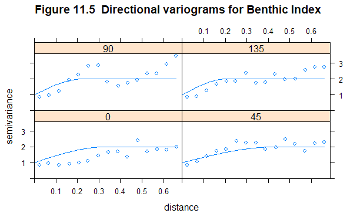

```r
benthic.dvg <- variogram(Index ~ 1,
                         data=benthic, alpha=c(0, 45,90,135))
benthic.dvg.fit <- vgm(1,"Sph", 0.5,1,anis=c(30,0.4))
plot(benthic.dvg, benthic.dvg.fit,
     main="Figure 11.5  Directional variograms for Benthic Index")
```